# Characterising Age assortativity using SA and clustering

Erik Volz

April 4, 2016

In this report:

- characterise age assortativity in baseline using SA out degree and cluster neighborhood size
- examine out degree and cluster size by age; is there an association?

Define some parameters of the analysis

```r
THRESHOLD_YRS <- Inf #10 # only count donors sampled within this many years of the most recent sample (control for cohort effects)
# NOTE this doesnt appear to be important for age, whereas it was important for stage, so setting to Inf

# Clustering threshold:
CL_THRESHOLD <- .015
```

Load stuff

```r
require(phydynR)
source('model0.R')
require(lattice)
lattice.options(default.theme = standard.theme(color=F))
```

Simulation file names:

```r
ratesBaselineFNS <- list.files('RData', full.names=T, path = 'model0-simulateBaseline0')
```

Helper functions to map a deme name to age and stage:

```r
deme2age <- function(deme){as.numeric( substr(regmatches( deme , regexpr( '\\.age[0-9]', deme )), 5,5) ) }
deme2stage <- function(deme){as.numeric( substr(regmatches( deme , regexpr( 'stage[0-9]', deme )), 6,6) ) }
```

This function does most of the work. It loads the given simulation file, computes out degree and cluster size, and returns a age-mixing matrix.

```r
fn2ageMatrix_table <- function(fn)
{#~ fn <- ratesBaselineFNS[1]{
    load(fn)
    samplesInCohort <- names(daytree$sampleTimes[daytree$sampleTimes > (max(daytree$sampleTimes)-THRESHOLD_YRS*365) ] )
    samplesInCohort_donors <- intersect( samplesInCohort, W$donor)

    i <- which( (W$donor %in% samplesInCohort) & (W$recip %in% samplesInCohort ) )
    WW <- list( donor = W$donor[i] , recip = W$recip[i], infectorProbability = W$infectorProbability[i] )

    #system.time({
    od <- sapply( samplesInCohort , function(u){
        if (!(u%in% samplesInCohort_donors)) return(0)
        i <- which(WW$donor==u)
        sum(WW$infectorProbability[i] )
    })
    #})

    age <- sapply( sampleDemes[ samplesInCohort ], deme2age )
    stage <- sapply( sampleDemes[ samplesInCohort ], deme2stage )

    amat = agemat <- matrix( 0, nrow=4, ncol=4)
    for (k in 1:length(WW$donor)){
        u <- WW$donor[k]
        v <- WW$recip[k]
        au <- deme2age( sampleDemes[ u] )
        av <- deme2age( sampleDemes[v] )
        amat[ au, av ] <- amat[ au, av ] + WW$infectorProbability[k]
    }
    rownames(amat) = colnames(amat) <- 1:4

    #load distance mat
    .dfn <-  strsplit( fn, '/' )[[1]]
    dfn <- paste( sep='/', paste(sep='-', .dfn[1], 'distances'), .dfn[2])
    load(dfn) #D
    DD <- D
    D1 <- daytree$tip.label[ D[1,] ]
    D2 <- daytree$tip.label[ D[2,] ]
    DD <- DD[ , (D1 %in% samplesInCohort) & (D2 %in% samplesInCohort) ]
    nbrhoodSize <- setNames( rep(0, length(samplesInCohort)), samplesInCohort )
    agemat2 <- matrix( 0, nrow = 4, ncol = 4 )
    for (k in 1:ncol(DD)){
        if (DD[3,k] < CL_THRESHOLD ) {
            u <- daytree$tip.label[ DD[1,k] ]
            v <- daytree$tip.label[ DD[2,k] ]
            au <- deme2age( sampleDemes[u] )
            av <- deme2age( sampleDemes[v])
            agemat2[au, av] <- agemat2[ au,av] + 1
            nbrhoodSize[u] <- nbrhoodSize[u] + 1
        }

    }
    print(date())
    print(fn)

    list(agemat = amat
     , agemat2 = agemat2
     , tab = data.frame(od=od, age=age, stage=stage , nbrhoodSize = nbrhoodSize)
     )
}
```

It takes a while to compute all the mixing matrices, so we will load the results

```r
if (F)
{
    fns2agemat_tables <- lapply( ratesBaselineFNS, fn2ageMatrix_table )
    save(fns2agemat_tables, file = 'age-anal0.0.RData')
} else{
    load('age-anal0.0.RData')
}
```

These functions compute the assortativity coefficient for the given mixing matrix & compute a *assortativity matrix*, which describes the extent to which links between age groups differ from the null expectation under random linking.

```r
# NOTE this is Newmans definition
mat2assortCoef <- function(mat)
{
    mat <- mat / sum(mat )
    rs <- rowSums(mat)
    cs <- colSums(mat)
    sum(diag(mat) - rs*cs) / (1 - sum(rs*cs))
}

mat2assortmat <- function(mat){
    rs <- rowSums(mat)
    cs <- colSums(mat)
    s <- sum(mat)
    M <- matrix(0, nrow=nrow(mat), ncol = ncol(mat))
    A <- matrix(0, nrow=nrow(mat), ncol = ncol(mat))
    k <- nrow(mat)
    for (i in 1:k) for (j in 1:k){
        M[i,j] <- rs[i] * cs[j] / s
        A[i,j] <- ( mat[i,j] - M[i,j] )/ M[i,j]
    }
    A
}
```

Now simulate the model in order to see what the ‘true’ assortativity is; this is based on the actual number of transmissions between age groups:

```r
o <- ode(y=y0, times=times_day, func=dydt, parms=list()  , method = 'adams')
tfgy <- .tfgy( o )
FF <- tfgy[[2]][[length(times_day)]]
fmat <- matrix(0, nrow = 4, ncol = 4)
for (k in 1:120) for (l in 1:120){
    fmat[ deme2age( DEMES[k] ), deme2age(DEMES[l]) ] <- fmat[ deme2age( DEMES[k] ), deme2age(DEMES[l]) ] + FF[k,l]
}
BASELINE_ASSRTCOEF <- mat2assortCoef( fmat )
print( 'True assortativity in baseline simulation')
```

```
## [1] "True assortativity in baseline simulation"
```

```r
print (BASELINE_ASSRTCOEF)
```

```
## [1] 0.3068812
```

Aggregate the mixing matrices for all the sims, compute assortativity, and plot;

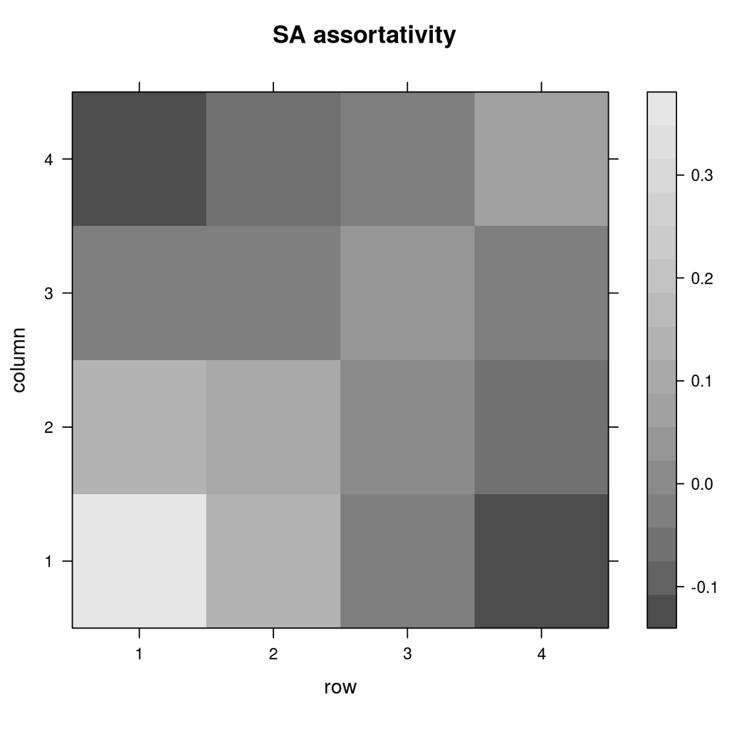

```r
    # make aggregate mixing matrices across all sims
    ag_amat <- fns2agemat_tables[[1]]$agemat
    for (i in 2:length(fns2agemat_tables)){
        ag_amat <- ag_amat + fns2agemat_tables[[i]]$agemat
    }
    # repeat this for clustering
    ag_amat2 <- fns2agemat_tables[[1]]$agemat2
    for (i in 2:length(fns2agemat_tables)){
        ag_amat <- ag_amat + fns2agemat_tables[[i]]$agemat2
    }
    # plot these with assort values also
    ag_assrt_amat <- mat2assortmat( ag_amat )
    ag_assrt_amat2 <- mat2assortmat( ag_amat2 )
    levelplot( ag_assrt_amat , main = 'SA assortativity')
```

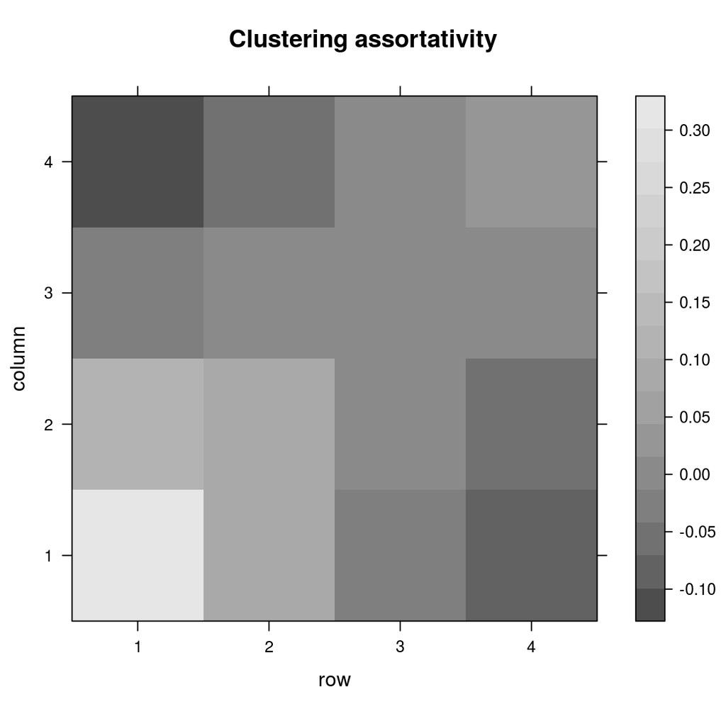

```r
    levelplot( ag_assrt_amat2, main = 'Clustering assortativity')
```

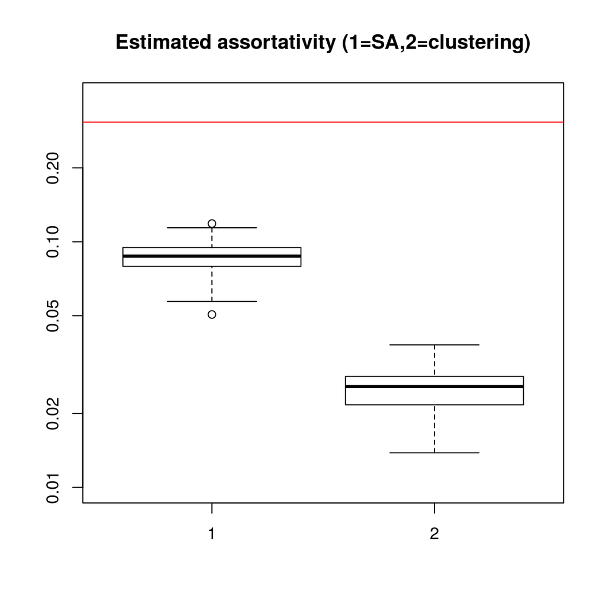

```r
    # compute assort coef for each sim; plot results with 'truth'
    assrt_coefs <- sapply( fns2agemat_tables, function(o){
        mat2assortCoef( o$agemat )
    })
    # repeat this for clustering
    assrt_coefs2 <- sapply( fns2agemat_tables, function(o){
        mat2assortCoef( o$agemat2 )
    })
    boxplot( list( assrt_coefs, assrt_coefs2 ), ylim = c(0.01, 1.25*BASELINE_ASSRTCOEF)
     , main='Estimated assortativity (1=SA,2=clustering)'
     , log = 'y')
    abline( h = BASELINE_ASSRTCOEF, col = 'red')
```

```r
    print('assortativity coefs for SA out degree')
```

```
## [1] "assortativity coefs for SA out degree"
```

```r
    print(summary( assrt_coefs))
```

```
##    Min. 1st Qu.  Median    Mean 3rd Qu.    Max.
## 0.05058 0.07952 0.08738 0.08722 0.09479 0.11860
```

```r
    print('assortativity coefs for clustering neighborhood size')
```

```
## [1] "assortativity coefs for clustering neighborhood size"
```

```r
    print(summary( assrt_coefs2))
```

```
##    Min. 1st Qu.  Median    Mean 3rd Qu.    Max.
## 0.01383 0.02177 0.02573 0.02526 0.02826 0.03806
```

Finally, since many clustering studies have found an association between age and cluster size, for each simulation we fit model of the form `y ~ as.factor(age) + as.factor(stage) + as.factor(stage)*as.factor(age)` where `y` is either out degree or neighborhood size. We then examine p-values to see if an independent effect of age is found. Note that in baseline simulations, transmission rate for all age groups is the same, so such a finding would be spurious.

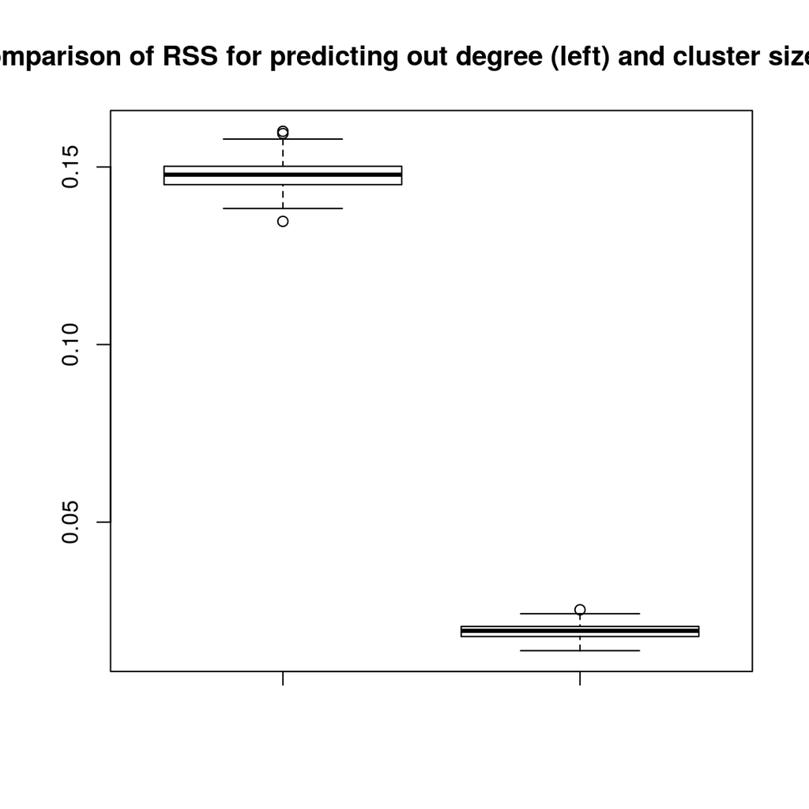

```r
    .summary2age_pvals <- function(s){
        coefs <- s$coefficients
        coefs[ (grepl('(age)', rownames(coefs), fixed=TRUE) & (!grepl('(stage)', rownames(coefs), fixed=TRUE))) , ncol(coefs ) ]
    }
    nbrhood_R2 <- c()
    nbrhood_age_ps <- c()
    for (i in 1:length(fns2agemat_tables)){
        tab <- fns2agemat_tables[[i]]$tab
        s <- summary( lm( scale(nbrhoodSize) ~ as.factor(age) + as.factor(stage) + as.factor(stage)*as.factor(age), data = tab ) )
        nbrhood_R2 <- c( nbrhood_R2 , s$r.squared )
        nbrhood_age_ps <- c( nbrhood_age_ps, .summary2age_pvals( s ) )
    }

    sa_R2 <- c()
    sa_age_ps <- c()
    for (i in 1:length(fns2agemat_tables)){
        tab <- fns2agemat_tables[[i]]$tab
        s <- summary( lm( scale(od) ~ as.factor(age) + as.factor(stage) + as.factor(stage)*as.factor(age), data = tab ) )
        sa_R2 <- c( sa_R2 , s$r.squared )
        sa_age_ps <- c( sa_age_ps, .summary2age_pvals( s ) )
    }

    boxplot( sa_R2, nbrhood_R2 , main = 'Comparison of RSS for predicting out degree (left) and cluster size(right)')
```

```r
    print( 'U test comparing SA RSS and clustering neighborhood size RSS:')
```

```
## [1] "U test comparing SA RSS and clustering neighborhood size RSS:"
```

```r
    print((wilcox.test( sa_R2, nbrhood_R2 )) )
```

```
##
##  Wilcoxon rank sum test with continuity correction
##
## data:  sa_R2 and nbrhood_R2
## W = 10000, p-value < 2.2e-16
## alternative hypothesis: true location shift is not equal to 0
```

```r
    print('SA out degree R2:')
```

```
## [1] "SA out degree R2:"
```

```r
    print(summary( sa_R2))
```

```
##    Min. 1st Qu.  Median    Mean 3rd Qu.    Max.
##  0.1347  0.1450  0.1478  0.1478  0.1502  0.1600
```

```r
    print('Clustering neighborhood size R2:')
```

```
## [1] "Clustering neighborhood size R2:"
```

```r
    print(summary( nbrhood_R2 ))
```

```
##    Min. 1st Qu.  Median    Mean 3rd Qu.    Max.
## 0.01383 0.01781 0.01941 0.01929 0.02066 0.02534
```

```r
    print ('proportion of p values for SA out degree that reach significance')
```

```
## [1] "proportion of p values for SA out degree that reach significance"
```

```r
    print( mean ( sa_R2  < .05 ))
```

```
## [1] 0
```

```r
    print ('proportion of p values for clustering neighborhood size that reach significance')
```

```
## [1] "proportion of p values for clustering neighborhood size that reach significance"
```

```r
    print( mean ( nbrhood_R2  < .05 ))
```

```
## [1] 1
```

## Conclusions

- Both methods underestimate true level of assortativity; this is not surprsing given incomplete sampling;
- SA assortativity is much close to truth and has greater power to detect assortativity
- Both methods find greatest assortativity in the youngest age group
- Clustering finds a spurious relationship between age and cluster size in all simulations; specifically it finds cluster size decreases with age, which is the same as in real data sets
- SA does not find any independent effect of age and outdegree after controlling for stage of infection